# Stable Isotopes for Archaeology: Data Visualization

C Stantis, PhD

Good data visualization helps you tell your data’s story with minimal misunderstanding.

Here I’m going to explain the datavis rules that I follow to create stable isotopes graphs, along with the associated R code. I’m going to use bone collagen data (carbon, nitrogen, sulphur, and strontium) from my [PhD Thesis](https://ourarchive.otago.ac.nz/handle/10523/6019). These are bone samples from individuals excavated from two Polynesian sites, Bourewa (Fiji) and `Atele (Tonga).

I’ve cleaned the data and put it in this repository as ThesisData.xlsx. Maybe later I’ll share some R tips for cleaning data, but today let’s focus on datavis. Let’s focus on one component at a time, thinking about **why** it might be better to go in one art direction rather than another, and the underlying R code for making your data follow this datavis rule.

Let’s build the graph, one piece at a time.

# The Background

I love dark themes. I’m writing in one of RStudio’s right now. But, unless you’re creating graphs for a dark-themed presentation or web output, graphs with black backgrounds aren’t going to work well in publication and **no one** will like you if they’re printing out your paper.

Some people like grid lines but I prefer a clean slate. The first image below is the carbon and nitrogen data plotted using ggplot, with no theme. The second image is the same data, but using the `theme_classic()` option.

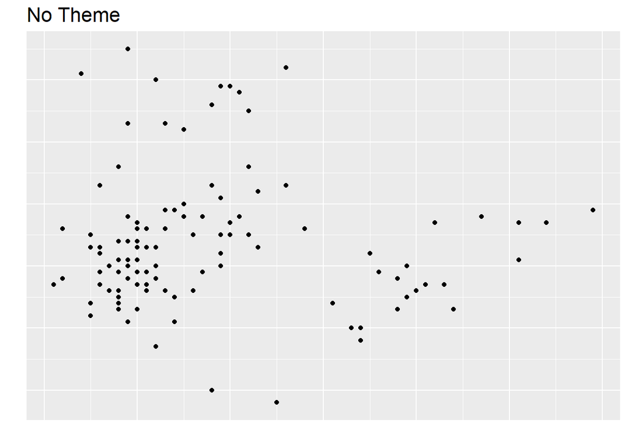

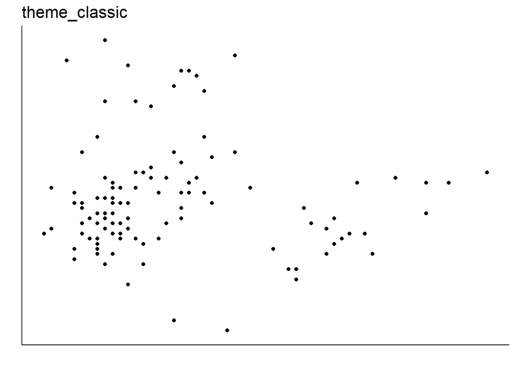

# Axis Text and Ticks

## Values

When displaying any interval data, don’t display any more decimal places than needed. Otherwise, the graph becomes increasingly difficult to read. Yes, I know that many stable isotopes data are presented to the first or even second decimal, you don’t need decimal points on your axes for isotope data other than strontium, save that richness of data for tables and text. This might be my biggest pet peeve for the smallest reason. It’s hard to add extraneous decimal places in R, so I’m mostly looking at you, Excel users.

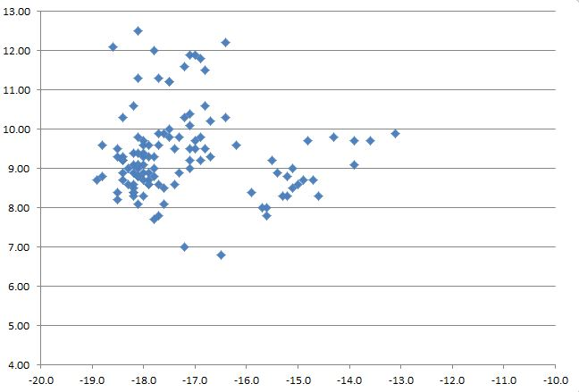

don’t do this.

Make sure the values text is large enough to read easily for most. Err on the side of caution, some publishers like to shove your figure into one column of a two-column article layout.

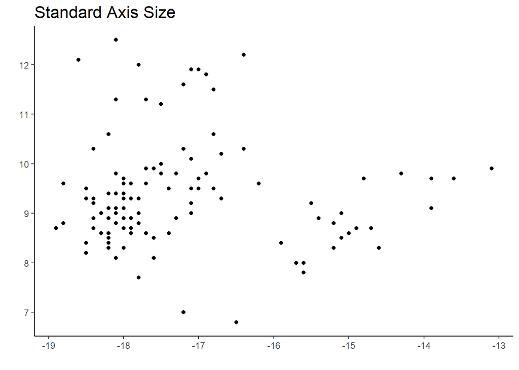

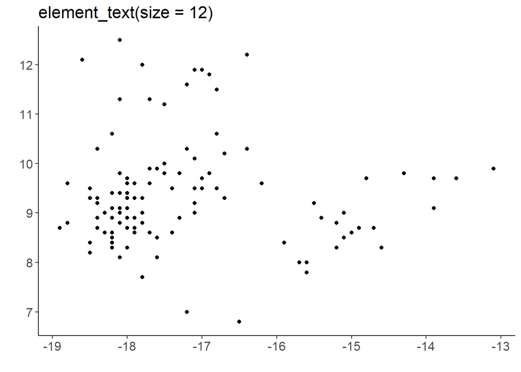

I sometimes angle the x-axis values because I think that makes me look fancy.

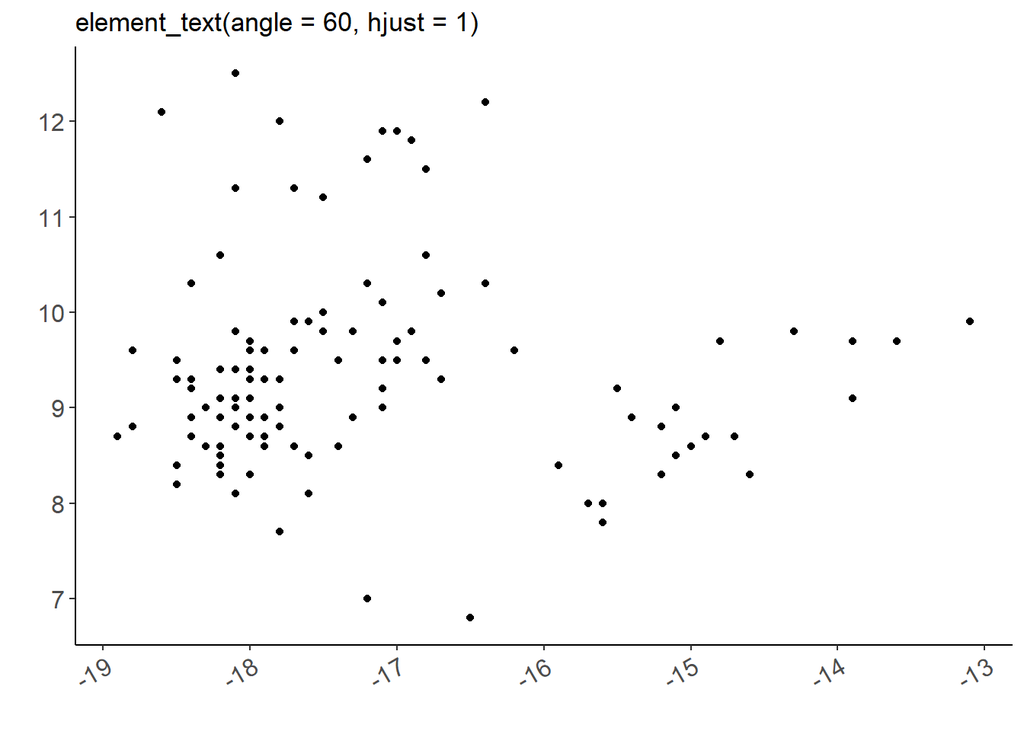

## Ticks and value range

Be mindful of the value range you use. R and Excel try to be helpful, but there’s two major ways they can be wrong.

### Starting at zero

Again, looking at you Excel.

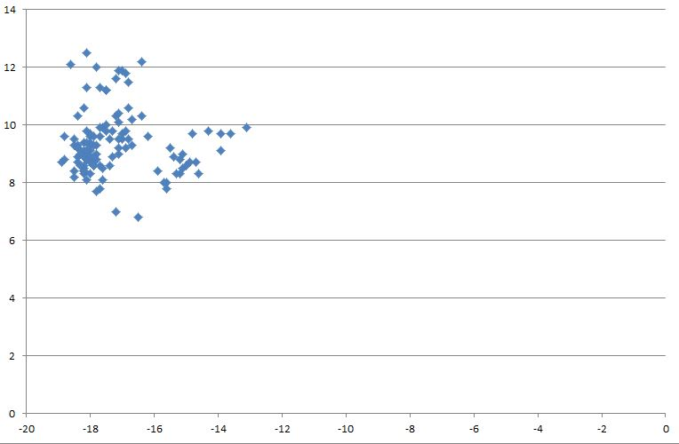

don’t do this either.

### Axis range too narrow

This one’s trickier, and I often see researchers still learning about stable isotopes make this mistake. A population eating only from a C3 environment with no C4 or marine input might show a range in C-values of only 2 per mill. That doesn’t mean your x-axis should only be 2 per mill across! This encourages you and your readers to think about differences in values on too small of a scale, and see patterns that aren’t biologically meanful. Even if values are tight, widen out to include the expected environmental range.

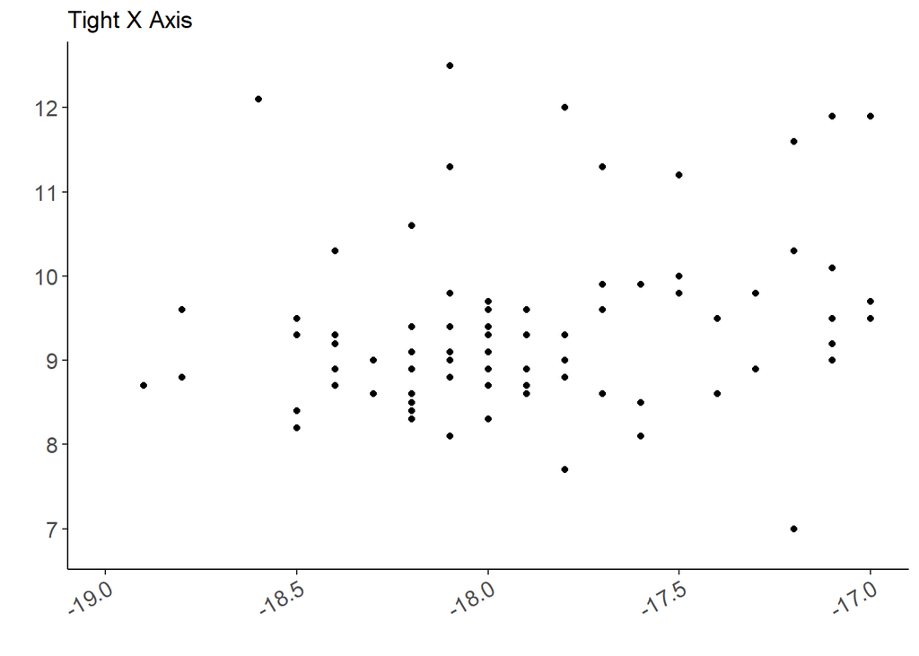

## Tick Units

Adjust your major units on the axes accordingly to the range you have. Too few tick marks, and it’s hard to estimate the values using the graph and the reader has to delve into your raw data. Too many tick marks, and it’s visually really busy. R likes to do it’s best, but don’t be afraid to be specific, especially for strontium data.

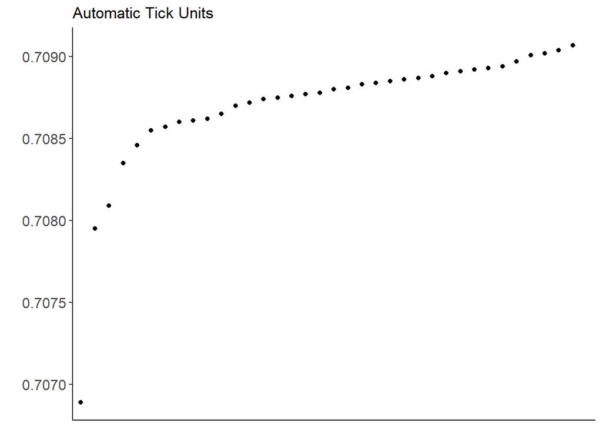

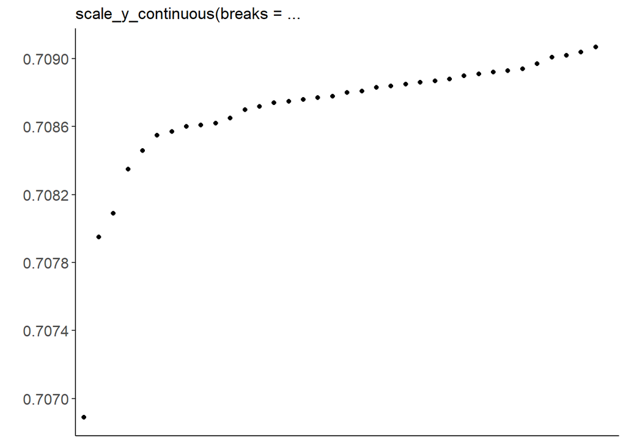

## Axis Titles

For each axis displaying isotopic values, you’ll want:

1. What’s being measured (e.g. $\delta ^{13}$C, $\delta ^{15}$N)
2. The unit (i.e. per mill ‰)
3. The international reference used

For `ggplot` the `labs` section is a big help, but it’s not easy to superscript, subscript, include Greek characters, or lesser used scientific units. Below is the code you can copy/paste for easy use in your own graphs. Change out `x` and `y` depending on what axis it’s on, and always remember to check that you’ve got matching brackets.

For carbon from collagen, standardized to VPDB: `x = (expression(paste(delta^13, "C"[collagen], " (\u2030, VPDB)")))`

Oxygen from carbonate, standarized to VSMOW, would look like this: `x = (expression(paste(delta^18, "O"[carbonate], " (\u2030, VSMOW)")))`

For strontium ratios: `y = (expression(paste(""^{87},"Sr/"^86,"Sr")))`

# Labels

Sometimes it’s nice to label the points. The package `ggrepel` let’s you make sure your text labels don’t overlap. My example of the basic graphics in ggplot a little harsh, as I could have used `hjust = 0, nudge_x = 0.05` to move the text off of the points, but you can see that `geom_text_repel` is quick and easy.

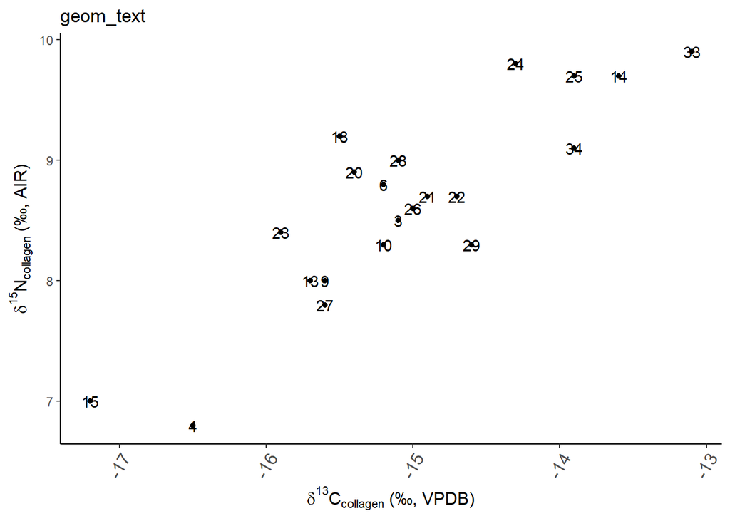

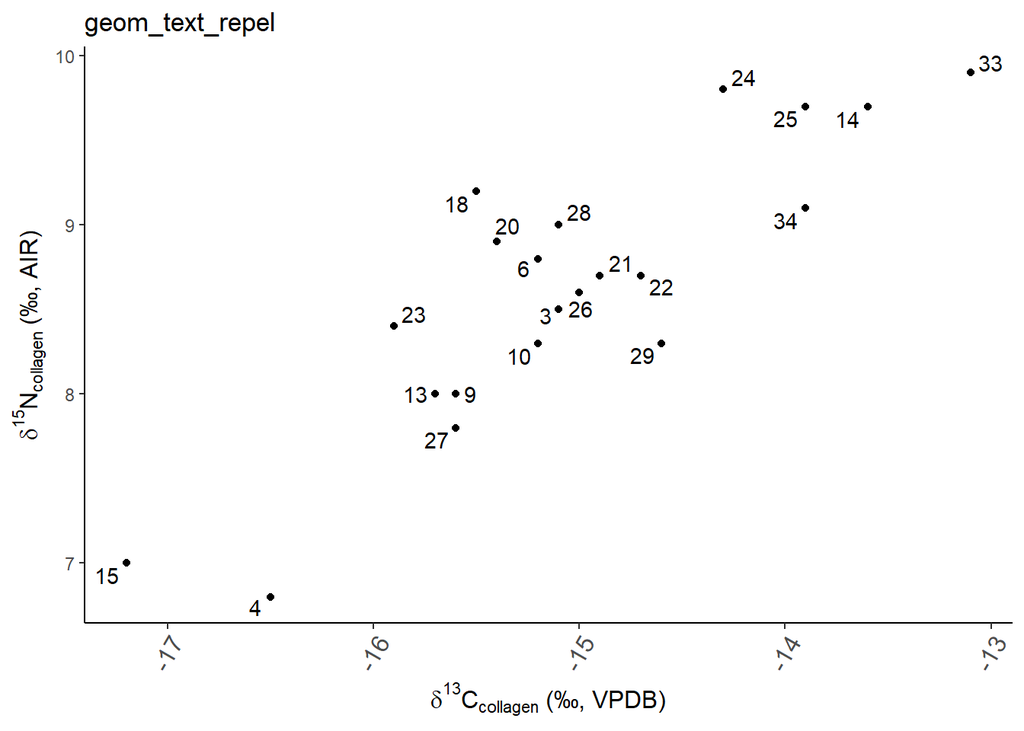

If you want to only label a few points on the graph, you can either `geom_text_repel` using the `data(subset = ...)` or `annotate('text')`

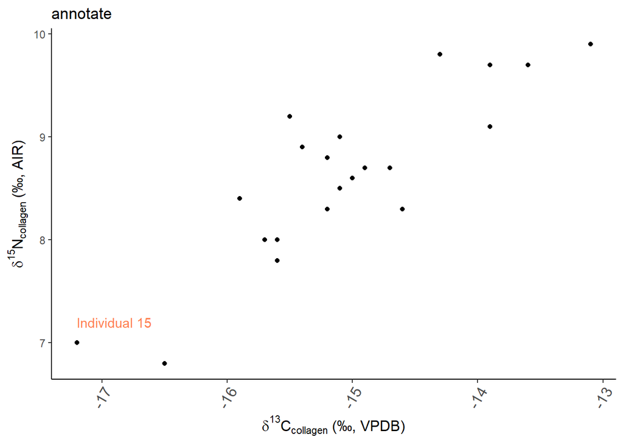

# The Data Points

This is my favorite part, where the graph really starts to shine.

## Size

I like to make the points a little bigger than the base size, so long as they’re not overlapping.

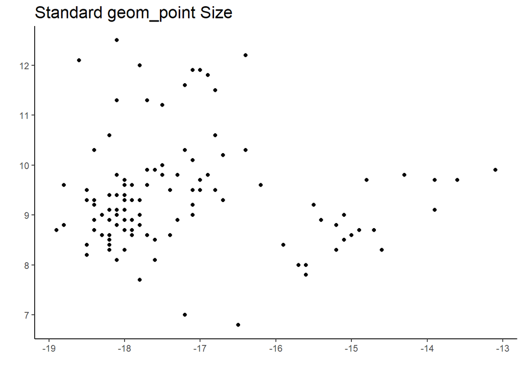

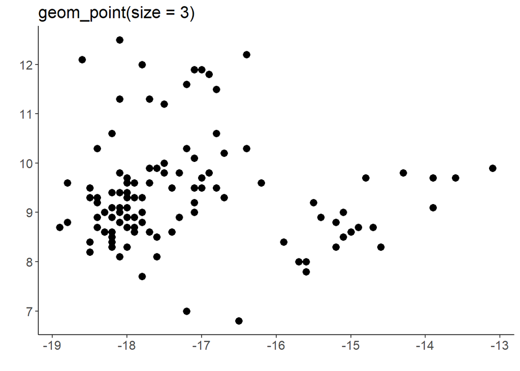

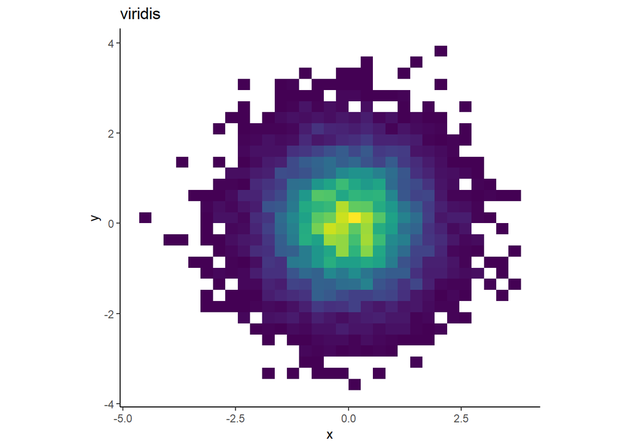

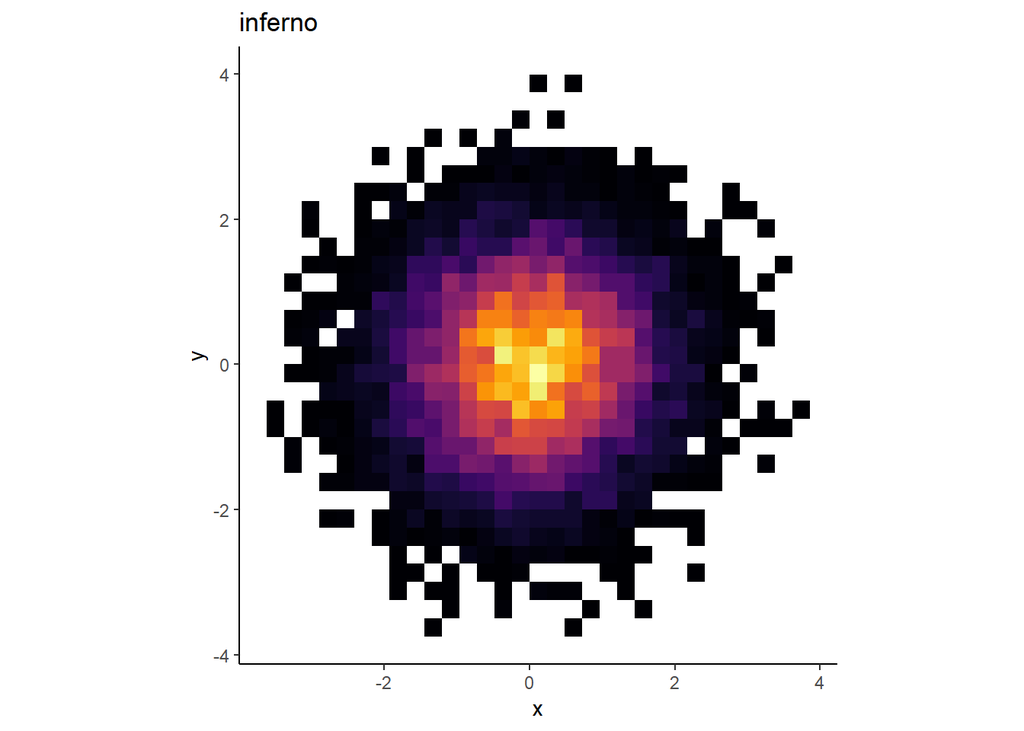

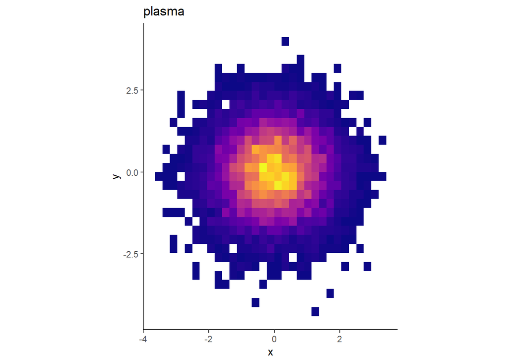

The Viridis package isn’t great for comparing two groups, so you’re best off coming up with your own color scheme at that point.

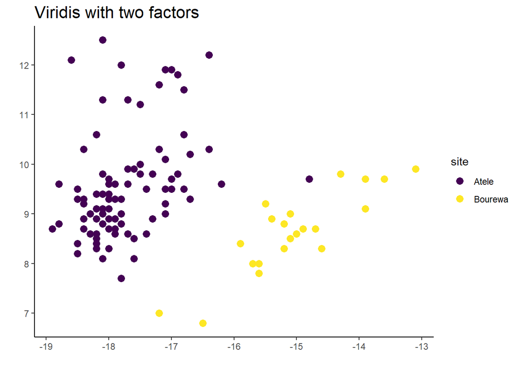

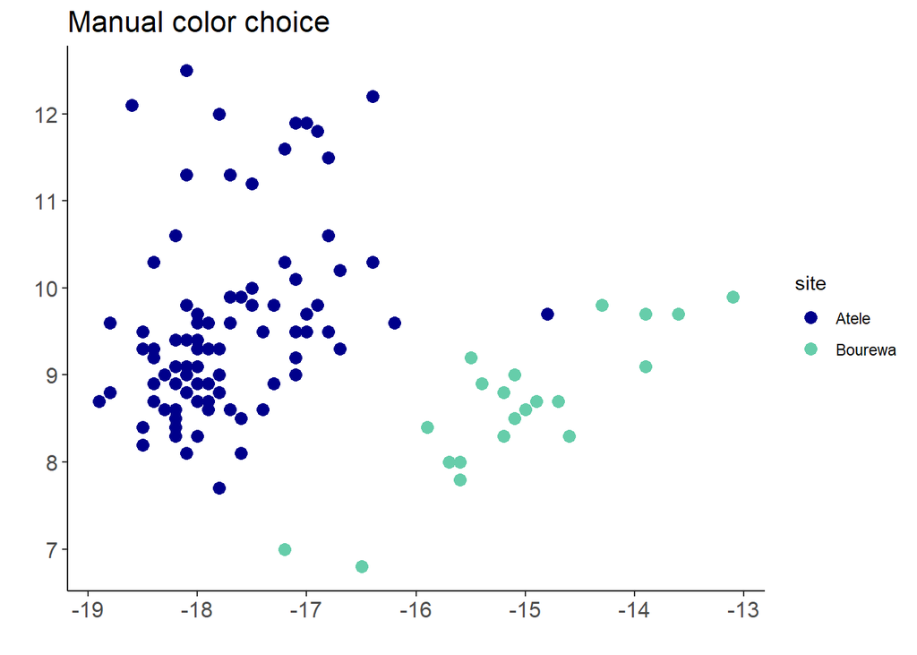

## Bar Graphs For Strontium?

No. Never.

# What are your thoughts?

This is an early version, please let me know what I’ve missed either through Github or through Twitter if you want to see more isotopes-specific graphing in R.